# Viewer Activity and Engagement Networks

Introduction, audit, and examples for reusable viewer-activity tools

## Purpose and model

This read-only notebook introduces the reusable viewer-activity tools. The canonical stored grain is one row per **talent, video, and identified chatter** in `analysis.viewer_video_activity`; it is refreshed by `r_scripts/run/publish_viewer_activity.R`.

```
flowchart LR
  U[User / chatter] -->|message_count| V[Video]
  V -->|hosted by| S[Streamer / talent]
```

```
flowchart LR
  U[User / chatter] -->|message_count| V[Video]
  V -->|hosted by| S[Streamer / talent]
```

The blue user–video edge represents collected chat participation, and its weight is messages sent in that video. The streamer link is ownership context, not engagement. This network does not represent viewers who watched without chatting.

| Field | Supports | Does not prove |
| --- | --- | --- |
| First observed chat | Earliest collected stream chat | First watch or original community entry |
| Public subscription date | Date reported in a matched public subscriber snapshot | Complete subscriber coverage or paid membership start |
| Membership event | Observed `membership_item` chat event | Original or uninterrupted membership |

## Reusable tools

The notebook is deliberately thin. Reusable responsibilities live in the library so reports, dashboards, and the Analyze Talent Data workflow can use the same definitions.

| Tool area | Main functions | Responsibility |
| --- | --- | --- |
| `lib/import_data/viewer_activity.R` | `load_viewer_video_activity()`, `load_viewer_profiles()` | Canonical lakehouse reads |
| `lib/dashboard/metrics/viewer_activity.R` | `viewer_activity_talent_summary()`, `viewer_activity_video_summary()` | General engagement numbers and participant tables |
| `lib/plots/domains/audience/viewer_activity.R` | `viewer_activity_bipartite_prep()`, `viewer_activity_bipartite_ggplot()` | Network-ready tables and graph rendering |

The stored `analysis.viewer_profiles` and `analysis.global_viewer_profiles` tables remain the reusable per-talent and cross-talent descriptive layers. User–user co-participation is a later, derived projection of the canonical user–video edges; it is not stored as a second edge table.

## Setup and audit

```r
required_packages <- c("DBI", "duckdb", "dplyr", "ggplot2", "here", "knitr", "scales")
missing_packages <- required_packages[!vapply(required_packages, requireNamespace, logical(1), quietly = TRUE)]
if (length(missing_packages) > 0L) {
  stop("Install the required R packages before rendering: ", paste(missing_packages, collapse = ", "), call. = FALSE)
}

suppressPackageStartupMessages(library(dplyr))
source(here::here("r_scripts", "lib", "utils", "repo_env.R"))
source(here::here("r_scripts", "lib", "utils", "datalake_root.r"))
source(here::here("r_scripts", "lib", "duckdb", "db_connect.R"))
source(here::here("r_scripts", "lib", "import_data", "viewer_activity.R"))
source(here::here("r_scripts", "lib", "dashboard", "metrics", "viewer_activity.R"))
source(here::here("r_scripts", "lib", "plots", "domains", "audience", "viewer_activity.R"))

load_repo_env(repo_root = here::here())
db_path <- talent_lakehouse_db_path()
if (!file.exists(db_path)) stop("Unified talent lakehouse not found: ", db_path, call. = FALSE)
con <- duckdb_connect(db_path = db_path, read_only = TRUE)

normalize_parameter <- function(value) {
  if (is.null(value) || length(value) == 0L || is.na(value[[1]])) return(NULL)
  value <- trimws(as.character(value[[1]]))
  if (nzchar(value)) value else NULL
}
display_table <- function(rows, digits = 1L) {
  if (nrow(rows) == 0L) return(knitr::kable(data.frame(message = "No rows matched.")))
  knitr::kable(rows, digits = digits)
}
positive_parameter <- function(value, default) {
  value <- suppressWarnings(as.integer(value))
  if (is.na(value) || value < 1L) default else value
}
talent_code <- normalize_parameter(params$talent_code)
video_id <- normalize_parameter(params$video_id)
profile_preview_limit <- positive_parameter(params$profile_preview_limit, 50L)
bipartite_max_videos <- positive_parameter(params$bipartite_max_videos, 12L)
bipartite_max_users <- positive_parameter(params$bipartite_max_users, 60L)
network_label_count <- positive_parameter(params$network_label_count, 15L)

required_relations <- data.frame(schema_name = c("text", "catalog", "clean", "analysis", "analysis", "analysis"), relation_name = c("chat_messages", "videos", "public_subscriber_snapshots", "viewer_video_activity", "viewer_profiles", "global_viewer_profiles"))
available_relations <- DBI::dbGetQuery(con, "SELECT table_schema AS schema_name, table_name AS relation_name FROM information_schema.tables")
required_relations <- required_relations %>% left_join(available_relations %>% mutate(available = TRUE), by = c("schema_name", "relation_name")) %>% mutate(available = coalesce(.data$available, FALSE), status = if_else(.data$available, "PASS", "FAIL"))
display_table(required_relations)
```

| schema_name | relation_name | available | status |
| --- | --- | --- | --- |
| text | chat_messages | TRUE | PASS |
| catalog | videos | TRUE | PASS |
| clean | public_subscriber_snapshots | TRUE | PASS |
| analysis | viewer_video_activity | TRUE | PASS |
| analysis | viewer_profiles | TRUE | PASS |
| analysis | global_viewer_profiles | TRUE | PASS |

```r
if (!all(required_relations$available)) stop("Run the viewer activity publisher before rendering.", call. = FALSE)
```

## Load the canonical activity and profile layers

```r
viewer_video_activity <- load_viewer_video_activity(con, talent_code) %>%
  mutate(stream_at = as.POSIXct(.data$stream_at, tz = "UTC"), active_minutes = .data$active_span_seconds / 60)
viewer_profiles <- load_viewer_profiles(con, talent_code) %>%
  mutate(observed_span_days = as.numeric(difftime(.data$last_observed_stream_at, .data$first_observed_stream_at, units = "days")))
if (nrow(viewer_video_activity) == 0L) stop("No collected chat activity matched the selected scope.", call. = FALSE)

display_table(data.frame(item = c("Database", "Talent scope", "User–video edges"), value = c(db_path, if (is.null(talent_code)) "All talents" else talent_code, nrow(viewer_video_activity))))
```

| item | value |
| --- | --- |
| Database | /mnt/storage/local/hdd01/DataLake/Sun_Data_Analytics/Talent_data/Data_lakehouse/talent_lakehouse.duckdb |
| Talent scope | All talents |
| User–video edges | 247962 |

## Reusable engagement numbers

These numbers come from `viewer_activity_talent_summary()`, so downstream workflows can use the same definitions without copying notebook calculations.

```r
talent_summary <- viewer_activity_talent_summary(viewer_profiles, viewer_video_activity)
display_table(talent_summary %>% mutate(messages = scales::comma(.data$messages), public_subscription_coverage = scales::percent(.data$public_subscription_coverage, accuracy = 0.1)))
```

| talent_code | talent_name | chatters | videos_with_chat | messages | median_videos_per_chatter | median_messages_per_chatter | public_subscription_matches | public_subscription_coverage | chatters_with_membership_events |
| --- | --- | --- | --- | --- | --- | --- | --- | --- | --- |
| AVA1 | Avaritia_Hawthorne_Variance_Project | 1978 | 140 | 161,174 | 1 | 5 | 287 | 14.5% | 133 |
| KAT2 | Katya_Sable_Variance_Project | 2798 | 129 | 190,228 | 2 | 5 | 124 | 4.4% | 62 |
| LEI3 | Leia_Memoria_Variance_Project | 2163 | 206 | 157,981 | 1 | 3 | 230 | 10.6% | 50 |
| NOV6 | Nova_Aokami_Ch | 37457 | 784 | 2,226,565 | 1 | 4 | 179 | 0.5% | 396 |
| RIU5 | Rius_Isonder_Ch | 603 | 294 | 42,160 | 1 | 7 | 73 | 12.1% | 1 |
| TER4 | Terberri_Solaris_Ch | 203 | 160 | 6,951 | 1 | 4 | 24 | 11.8% | 0 |

```r
video_summary <- viewer_activity_video_summary(viewer_video_activity)
display_table(slice_head(video_summary, n = 20L))
```

| talent_code | video_id | video_title | stream_at | chatters | messages | paid_messages | membership_events |
| --- | --- | --- | --- | --- | --- | --- | --- |
| NOV6 | Rtxch6pjNfU | Can I Reach Master rank in 12 HOURS??【YU-GI-OH MASTER DUEL】 | 2023-06-25 16:03:35 | 835 | 12680 | 17 | 14 |
| NOV6 | AVlTzN9ywjw | 【DONOTHON】Playing Card Games For 12 HOURS | 2023-04-22 16:03:28 | 655 | 11492 | 21 | 15 |
| NOV6 | nxrBTRql7GM | 【FATE/GRAND ORDER】FGO SMASH OR PASS | 2023-05-13 00:01:30 | 455 | 10100 | 14 | 14 |
| NOV6 | qN_pbEbUoQE | 【FATE/GRAND ORDER】It’s The 6th anniversary!! There’s free SSRs?! | 2023-07-11 00:09:02 | 771 | 10087 | 27 | 9 |
| NOV6 | nO3EyIo6BDM | 【YUGIOH MASTER DUEL】Dueling Viewers For 12 Hours!! | 2025-10-12 16:03:37 | 671 | 9142 | 35 | 10 |
| NOV6 | U-87P2I7rRM | 【YU-GI-OH MASTER DUEL】Climbing to Platinum pt.2【VTUBER】 | 2022-05-22 01:00:35 | 479 | 9082 | 13 | 0 |
| NOV6 | 0rA_0d-KBlo | 【FATE/GRAND ORDER】First Time Playing! | 2023-02-10 01:00:34 | 429 | 8918 | 28 | 13 |
| NOV6 | Yf6IlNG6O9c | 【YU-GI-OH MASTER DUEL】How Good Is Jaden Yuki’s Deck? | 2023-01-17 02:02:32 | 644 | 8669 | 24 | 7 |
| NOV6 | uy5ge7RaBn4 | 【FATE/GRAND ORDER】Oberon Is HERE!! | 2023-07-20 00:22:34 | 629 | 8160 | 10 | 4 |
| NOV6 | DW7hOzD9eX0 | 【FATE/GRAND ORDER】It’s The 8th anniversary!! It’s Time For GSSR !! | 2025-07-08 01:02:34 | 377 | 8097 | 14 | 7 |
| NOV6 | YHNnvSoQQs4 | It’s FGOs 7th Anniversary! Let’s Gacha!! | 2024-07-11 01:06:32 | 457 | 8089 | 11 | 3 |
| NOV6 | pQVt7El3Bb0 | 【FATE/GRAND ORDER】Let’s Gatcha On The Valentine’s Event!! | 2023-02-16 01:05:36 | 362 | 7835 | 4 | 1 |
| NOV6 | 0ZpMJyRh86o | Oberon is BACK !! Lets Gacha !! 【FATE/GRAND ORDER】 | 2024-12-17 02:08:27 | 477 | 7599 | 15 | 9 |
| NOV6 | M6dsOmpwVCw | 【YU-GI-OH MASTER DUEL】Labrynth Is Best Mommy | 2023-01-21 02:00:59 | 497 | 7512 | 11 | 4 |
| NOV6 | fIV281wbC10 | 【YU-GI-OH MASTER DUEL】Spright Is HERE!! How Will It Affect The Meta? | 2023-02-19 01:07:37 | 594 | 7394 | 18 | 4 |
| NOV6 | iYs_jH8iN0I | 【YU-GI-OH MASTER DUEL】Streaming Till I Hit 20k Subs!【VTUBER】 | 2022-11-05 00:59:52 | 568 | 7328 | 21 | 5 |
| NOV6 | 55D18tYsy1Q | 【FATE/GRAND ORDER】Nero Fest Is HERE!!! | 2023-08-01 01:02:22 | 558 | 7183 | 9 | 5 |
| NOV6 | BO5sdMOENQ8 | 【YU-GI-OH MASTER DUEL】How Good Is Kaiba’s Battle City Deck? | 2023-01-03 03:02:42 | 547 | 7144 | 16 | 4 |
| NOV6 | iDUmai2ZsAg | 【YU-GI-OH MASTER DUEL】Teaching A Vtuber How To Play YU-GI-OH! @YurikagoKokone | 2022-12-29 02:04:54 | 496 | 7088 | 4 | 3 |
| NOV6 | wOaRVfSDlCM | 【YU-GI-OH MASTER DUEL】So Ariseheart is Here…… | 2023-10-15 00:04:26 | 657 | 6936 | 22 | 14 |

```r
if (!is.null(video_id)) {
  display_table(viewer_activity_video_participants(viewer_video_activity, video_id, profile_preview_limit))
}
```

## User–video engagement graph

`viewer_activity_bipartite_prep()` returns ordinary node and edge tables as well as the graph-ready coordinates. Use those tables directly in a dashboard, table, or another graphing system; this notebook uses the paired ggplot helper.

```r
engagement_network <- viewer_activity_bipartite_prep(
  viewer_video_activity,
  video_id = video_id,
  max_videos = bipartite_max_videos,
  max_users = bipartite_max_users
)

display_table(slice_head(engagement_network$engagement_edges %>% select(.data$user_id, .data$video_id, .data$message_count), n = 20L))
```

| user_id | video_id | message_count |
| --- | --- | --- |
| UC-PszenHindF–QCtjWUPWg | U-87P2I7rRM | 119 |
| UC6Oy5i5HHG2gt6iZ1kgAhVg | U-87P2I7rRM | 103 |
| UCE6Fd_tBCPmi65ZVXes1rTA | U-87P2I7rRM | 113 |
| UCEcNQeZenjEsckdDuYzFZUQ | U-87P2I7rRM | 16 |
| UCEp6fpLmc8_PJz02UpZEeFw | U-87P2I7rRM | 7 |
| UCHcR303cjvlKQaQ9lKRVSHw | U-87P2I7rRM | 115 |
| UCJ-orXRESlQQ4J6p291e7FQ | U-87P2I7rRM | 173 |
| UCJ6OPpzDc7N06rKtsWyVAVw | U-87P2I7rRM | 209 |
| UCKlU-TjrWn0r4CkQmbmVxTQ | U-87P2I7rRM | 202 |
| UCM_y_YfrUUwQUK0jXjZu64Q | U-87P2I7rRM | 5 |
| UCOKWRfedvuUUetCXlo-N-Hw | U-87P2I7rRM | 158 |
| UCTjDbNitX3j4ddv2XId-_1A | U-87P2I7rRM | 244 |
| UCTmx_wixvFct8GNQwfwLxBQ | U-87P2I7rRM | 42 |
| UCjTRhWKZJHC7RO6Gxsqcdyw | U-87P2I7rRM | 143 |
| UCnbLHDpJ4CCyXKDT46BnTcw | U-87P2I7rRM | 35 |
| UCtHyerdcTBSfLS8XL53Ctvg | U-87P2I7rRM | 21 |
| UCwBMZva-XW1gPLbC4Rx7Xyw | U-87P2I7rRM | 33 |
| UCwlimRV6sgvHC6oD_-LbUtg | U-87P2I7rRM | 452 |
| UCwvW_n9w-K0VflJ3KRiuLwQ | U-87P2I7rRM | 213 |
| UC02Wg259lSvWoiMHMtiAwrQ | Yf6IlNG6O9c | 46 |

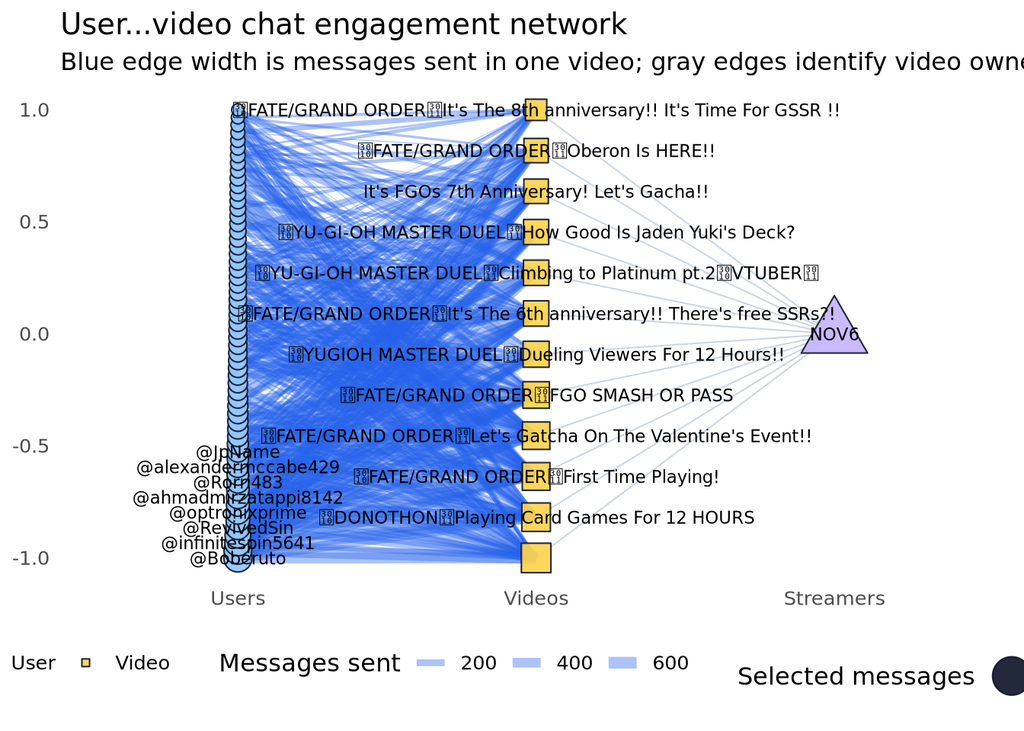

```r
engagement_plot <- viewer_activity_bipartite_ggplot(engagement_network, network_label_count)
if (is.null(engagement_plot)) {
  plot.new()
  graphics::text(0.5, 0.5, "No user–video chat edges matched the selected scope.")
} else {
  print(engagement_plot)
}
```

## Profile review surface

```r
profile_preview <- viewer_profiles %>%
  arrange(desc(.data$videos_chatted_in), desc(.data$total_messages), .data$talent_code, .data$user_id) %>%
  select(.data$talent_code, .data$user_id, .data$current_username, .data$first_observed_stream_at, .data$last_observed_stream_at, .data$videos_chatted_in, .data$total_messages, .data$paid_messages, .data$membership_events, .data$subscribed_at, .data$public_subscription_matched, .data$subscription_date_changed) %>%
  slice_head(n = profile_preview_limit)
display_table(profile_preview)
```

| talent_code | user_id | current_username | first_observed_stream_at | last_observed_stream_at | videos_chatted_in | total_messages | paid_messages | membership_events | subscribed_at | public_subscription_matched | subscription_date_changed |
| --- | --- | --- | --- | --- | --- | --- | --- | --- | --- | --- | --- |
| NOV6 | UCoam0R7NIRieMb1bkrhCxUw | @MysteryOtakuYT | 2022-04-09 01:01:03 | 2026-07-04 01:02:39 | 701 | 5834 | 54 | 42 | NA | FALSE | FALSE |
| NOV6 | UCwBMZva-XW1gPLbC4Rx7Xyw | @DAMPERSANDD | 2022-03-19 01:01:32 | 2026-07-04 01:02:39 | 678 | 16121 | 11 | 8 | NA | FALSE | FALSE |
| NOV6 | UC1AjewgFp0qcdmFRowUjLxg | @gospel2373 | 2022-10-09 01:02:36 | 2026-07-04 01:02:39 | 642 | 17899 | 0 | 3 | NA | FALSE | FALSE |
| NOV6 | UCJZPk5VC3MNRMlw-E3haskw | @Boberuto | 2022-05-25 01:00:28 | 2026-07-04 01:02:39 | 623 | 59192 | 9 | 46 | NA | FALSE | FALSE |
| NOV6 | UCAwISz_ZyIVkE70gs9foitA | @JpName | 2022-04-26 01:00:12 | 2026-06-15 01:01:01 | 591 | 29146 | 0 | 5 | NA | FALSE | FALSE |
| NOV6 | UCoScyy5aYHWNND1LfMbYycg | @sentaikng | 2022-08-30 01:03:20 | 2026-07-04 01:02:39 | 581 | 8180 | 0 | 30 | NA | FALSE | FALSE |
| NOV6 | UCA4bOB1Jnw5-lbuoSCfxc-w | @NovaAokami | 2022-03-19 01:01:32 | 2026-06-30 01:08:49 | 577 | 1937 | 0 | 0 | NA | FALSE | FALSE |
| NOV6 | UCJ-orXRESlQQ4J6p291e7FQ | @greedo1531 | 2022-05-18 01:01:10 | 2026-07-02 01:04:02 | 576 | 51733 | 0 | 19 | NA | FALSE | FALSE |
| NOV6 | UCHcR303cjvlKQaQ9lKRVSHw | @jwxu81688 | 2022-05-01 01:16:38 | 2026-07-04 01:02:39 | 556 | 25559 | 21 | 42 | NA | FALSE | FALSE |
| NOV6 | UCxovw1LkAgyxsdJrALCW_Lg | @bryangarza254 | 2022-03-19 01:01:32 | 2026-03-28 01:01:17 | 538 | 5122 | 0 | 2 | NA | FALSE | FALSE |
| NOV6 | UC0N5Y1EN2nNaE1Fzj4nZOUQ | @bknight045 | 2022-08-14 01:00:42 | 2026-07-04 01:02:39 | 523 | 8900 | 12 | 25 | NA | FALSE | FALSE |
| NOV6 | UCOceU5avE4D4GiZdA2m1jPQ | @RyuNarukami | 2022-06-10 01:00:26 | 2026-07-04 01:02:39 | 523 | 2716 | 64 | 23 | NA | FALSE | FALSE |
| NOV6 | UCm_e9SsNdaKg0EDYzOl0k2w | @gyroshard | 2022-11-13 02:07:28 | 2026-07-04 01:02:39 | 513 | 12278 | 0 | 9 | NA | FALSE | FALSE |
| NOV6 | UCo3G5TnQEEcU4NYOIngM1zA | @simonkwan8140 | 2022-04-16 01:01:22 | 2026-07-04 01:02:39 | 498 | 1161 | 10 | 0 | NA | FALSE | FALSE |
| NOV6 | UCDcR4_WsD9AoG_l31xfPHiA | @infinitespin5641 | 2022-10-09 01:02:36 | 2025-10-17 22:01:46 | 495 | 41424 | 0 | 9 | NA | FALSE | FALSE |
| NOV6 | UCfra8JMq7U9aEeUwy6A7G5Q | @optronixprime | 2022-09-06 01:01:18 | 2026-07-04 01:02:39 | 492 | 14714 | 4 | 2 | NA | FALSE | FALSE |
| NOV6 | UCEcNQeZenjEsckdDuYzFZUQ | @TheGoodDarkMage | 2022-04-17 01:03:07 | 2026-07-04 01:02:39 | 478 | 5794 | 0 | 0 | NA | FALSE | FALSE |
| NOV6 | UCaWRcEzEipcyEGDlop8fsFA | @dragonkingbrandon | 2022-10-04 01:00:49 | 2026-07-04 01:02:39 | 462 | 10012 | 2 | 33 | NA | FALSE | FALSE |
| NOV6 | UCjTRhWKZJHC7RO6Gxsqcdyw | @EstukoV | 2022-03-22 01:01:22 | 2026-06-22 01:05:14 | 459 | 22629 | 0 | 10 | NA | FALSE | FALSE |
| NOV6 | UCOKWRfedvuUUetCXlo-N-Hw | @ecpsuper2010 | 2022-03-31 01:00:45 | 2026-05-27 01:06:34 | 441 | 23218 | 261 | 35 | NA | FALSE | FALSE |
| NOV6 | UCBSGcbE9ja5fZv7XhYtdrwA | @Slayerthecrow | 2022-05-22 01:00:35 | 2026-06-30 01:08:49 | 433 | 4337 | 8 | 1 | NA | FALSE | FALSE |
| NOV6 | UCJ6OPpzDc7N06rKtsWyVAVw | @KyuSharp | 2022-03-22 01:01:22 | 2026-06-16 01:01:54 | 427 | 20456 | 0 | 7 | NA | FALSE | FALSE |
| NOV6 | UChpuXnbZqWDCJ-1yvrRhqAQ | @RyuVanguard | 2022-10-13 01:04:42 | 2026-07-02 01:04:02 | 419 | 8269 | 38 | 20 | NA | FALSE | FALSE |
| NOV6 | UCNL8jaJ9hId96P13QmQXNtA | @Streamlabs | 2022-03-19 01:01:32 | 2025-11-30 02:09:19 | 417 | 10123 | 0 | 0 | NA | FALSE | FALSE |
| NOV6 | UCEp6fpLmc8_PJz02UpZEeFw | @LondricL | 2022-05-18 01:01:10 | 2026-06-30 01:08:49 | 399 | 5895 | 26 | 30 | NA | FALSE | FALSE |
| NOV6 | UCdMOXPO1JChzYXv7Re4GleQ | @RevivedSin | 2022-12-26 02:02:08 | 2026-07-04 01:02:39 | 392 | 34193 | 6 | 38 | NA | FALSE | FALSE |
| NOV6 | UCrwoT6tJxcva0sAFuS2BFpw | @EastCoastMikeP | 2023-10-10 00:00:48 | 2026-07-04 01:02:39 | 343 | 3220 | 0 | 27 | NA | FALSE | FALSE |
| NOV6 | UC-PszenHindF–QCtjWUPWg | @amaze865 | 2022-04-26 01:00:12 | 2026-03-07 02:08:19 | 335 | 4621 | 5 | 37 | NA | FALSE | FALSE |
| NOV6 | UCBbORZtZLOHTbco4_zaDLMg | @animefreak123ization | 2022-03-19 01:01:32 | 2025-11-14 02:05:28 | 333 | 339 | 0 | 0 | NA | FALSE | FALSE |
| NOV6 | UC5vW0a7kBUoF2liFeBBlXDw | @rionofbahamut9751 | 2023-05-08 00:00:32 | 2026-03-28 01:01:17 | 329 | 3788 | 0 | 0 | NA | FALSE | FALSE |
| NOV6 | UCC1fwNPmcfeR41u_iSoyZQw | @jrpgjunkie8326 | 2023-08-15 00:11:40 | 2026-05-28 01:11:59 | 326 | 4546 | 1 | 25 | NA | FALSE | FALSE |
| NOV6 | UCox92HSMlddq89BRMn7x_pg | @necro3013 | 2024-07-25 01:09:02 | 2026-07-04 01:02:39 | 308 | 15752 | 126 | 19 | NA | FALSE | FALSE |
| NOV6 | UCBgFVX1lc-6i8Pc3aQakn7g | @NeoSight337 | 2022-10-04 01:00:49 | 2026-07-04 01:02:39 | 303 | 2244 | 1 | 2 | NA | FALSE | FALSE |
| NOV6 | UC88XyuDfVoNpXk9BqVvgeow | @lizzzbenoist | 2022-04-17 01:03:07 | 2026-06-15 01:01:01 | 301 | 6947 | 0 | 7 | NA | FALSE | FALSE |
| NOV6 | UCY2SShkVe9cRnFtIJszyxvQ | @diabesttrainer4069 | 2022-06-03 01:01:10 | 2026-07-04 01:02:39 | 299 | 2561 | 0 | 0 | NA | FALSE | FALSE |
| NOV6 | UCtHyerdcTBSfLS8XL53Ctvg | @alexandermccabe429 | 2022-03-19 01:01:32 | 2026-05-18 01:05:09 | 298 | 6140 | 20 | 27 | NA | FALSE | FALSE |
| NOV6 | UCEPTRl-B0A-7kB1_Evd7bdQ | @VtuberTimestamper | 2022-03-24 01:00:48 | 2026-06-22 01:05:14 | 296 | 39943 | 0 | 4 | NA | FALSE | FALSE |
| NOV6 | UC1ReXNomc-fh_wWP9wLG6Cg | @Prisma_B | 2022-12-29 02:04:54 | 2026-07-02 01:04:02 | 294 | 7351 | 0 | 0 | NA | FALSE | FALSE |
| NOV6 | UCmX7TeByXF2SeddUMbtRL7g | @sunnyshine4513 | 2022-08-07 01:00:39 | 2026-07-04 01:02:39 | 289 | 5689 | 0 | 0 | NA | FALSE | FALSE |
| NOV6 | UCnbLHDpJ4CCyXKDT46BnTcw | @losimeek5193 | 2022-04-28 01:00:16 | 2026-03-10 01:13:19 | 289 | 4835 | 0 | 24 | NA | FALSE | FALSE |
| NOV6 | UCaqbETwz5TILaZSTMezj-KQ | @firepuppies4086 | 2022-07-16 01:00:20 | 2026-07-04 01:02:39 | 285 | 6658 | 6 | 28 | NA | FALSE | FALSE |
| NOV6 | UC02Wg259lSvWoiMHMtiAwrQ | @GuilhermeDiGiorgi | 2022-07-17 01:01:22 | 2026-07-04 01:02:39 | 271 | 5578 | 2 | 2 | NA | FALSE | FALSE |
| NOV6 | UC0kXlufMF1yR6PsXdnqDklA | @michaelglbrt17 | 2023-10-25 00:12:50 | 2026-06-27 01:04:20 | 268 | 2689 | 0 | 0 | NA | FALSE | FALSE |
| NOV6 | UChT2JWezQVUoZT49l2yh-Pg | @jesufranc | 2022-05-25 01:00:28 | 2026-06-15 01:01:01 | 261 | 2665 | 15 | 0 | NA | FALSE | FALSE |
| NOV6 | UCI1EO6EWgGQ-r6yGDEsY72g | @RGuy1011 | 2023-02-25 01:02:54 | 2026-07-04 01:02:39 | 250 | 5831 | 2 | 0 | NA | FALSE | FALSE |
| NOV6 | UCNtMf2LF2adST64-gma81xQ | @Eeveeolite655 | 2022-10-02 01:02:02 | 2024-12-10 02:05:31 | 246 | 2070 | 8 | 1 | NA | FALSE | FALSE |
| NOV6 | UCKlU-TjrWn0r4CkQmbmVxTQ | @MitchPich | 2022-05-20 01:00:26 | 2026-05-27 01:06:34 | 245 | 15543 | 7 | 23 | NA | FALSE | FALSE |
| NOV6 | UC-4Rb–Z_WYBojfHZIBZBMw | @hiro_128 | 2023-07-10 00:02:28 | 2026-05-28 01:11:59 | 243 | 7446 | 5 | 29 | NA | FALSE | FALSE |
| NOV6 | UC34vIGDm91V14HOoyYLjkXg | @nova-kamo | 2022-11-06 01:02:31 | 2025-07-04 01:06:59 | 243 | 1649 | 2 | 9 | NA | FALSE | FALSE |
| NOV6 | UCmiZQmmOL7adsAdWv6JwFCA | @crestfallenhussar | 2022-05-29 01:01:30 | 2026-06-21 01:04:03 | 240 | 3831 | 0 | 6 | NA | FALSE | FALSE |

## Operating notes

1. Refresh the canonical activity tables with `publish_viewer_activity.R`; it defaults to a dry run.
2. Use the import and metric helpers for repeatable counts in analysis workflows.
3. Use the plotting helper only after selecting a readable scope; do not treat a visual bound as a population filter.
4. Keep subscription dates and first-observed chat dates qualified as described above.